# Risk Factor Analysis

## Outcome Variable

**Outcome Variable:** pers_wasted624

## Predictor Variables

**Intervention Variable:** ever_wasted06

**Adjustment Set:**

unadjusted

## Stratifying Variables

The analysis was stratified on these variable(s):

- studyid
- country

## Data Summary

| studyid | country | ever_wasted06 | pers_wasted624 | n_cell | n | outcome_variable |
| --- | --- | --- | --- | --- | --- | --- |
| CMC-V-BCS-2002 | INDIA | 0 | 0 | 175 | 370 | pers_wasted624 |
| CMC-V-BCS-2002 | INDIA | 0 | 1 | 3 | 370 | pers_wasted624 |
| CMC-V-BCS-2002 | INDIA | 1 | 0 | 167 | 370 | pers_wasted624 |
| CMC-V-BCS-2002 | INDIA | 1 | 1 | 25 | 370 | pers_wasted624 |
| CMIN | BANGLADESH | 0 | 0 | 196 | 252 | pers_wasted624 |
| CMIN | BANGLADESH | 0 | 1 | 11 | 252 | pers_wasted624 |
| CMIN | BANGLADESH | 1 | 0 | 31 | 252 | pers_wasted624 |
| CMIN | BANGLADESH | 1 | 1 | 14 | 252 | pers_wasted624 |
| COHORTS | GUATEMALA | 0 | 0 | 786 | 1017 | pers_wasted624 |
| COHORTS | GUATEMALA | 0 | 1 | 25 | 1017 | pers_wasted624 |
| COHORTS | GUATEMALA | 1 | 0 | 190 | 1017 | pers_wasted624 |
| COHORTS | GUATEMALA | 1 | 1 | 16 | 1017 | pers_wasted624 |
| COHORTS | INDIA | 0 | 0 | 4756 | 6892 | pers_wasted624 |
| COHORTS | INDIA | 0 | 1 | 113 | 6892 | pers_wasted624 |
| COHORTS | INDIA | 1 | 0 | 1366 | 6892 | pers_wasted624 |
| COHORTS | INDIA | 1 | 1 | 657 | 6892 | pers_wasted624 |
| COHORTS | PHILIPPINES | 0 | 0 | 2013 | 2808 | pers_wasted624 |
| COHORTS | PHILIPPINES | 0 | 1 | 98 | 2808 | pers_wasted624 |
| COHORTS | PHILIPPINES | 1 | 0 | 569 | 2808 | pers_wasted624 |
| COHORTS | PHILIPPINES | 1 | 1 | 128 | 2808 | pers_wasted624 |
| CONTENT | PERU | 0 | 0 | 211 | 215 | pers_wasted624 |
| CONTENT | PERU | 0 | 1 | 0 | 215 | pers_wasted624 |
| CONTENT | PERU | 1 | 0 | 4 | 215 | pers_wasted624 |
| CONTENT | PERU | 1 | 1 | 0 | 215 | pers_wasted624 |
| EE | PAKISTAN | 0 | 0 | 234 | 374 | pers_wasted624 |
| EE | PAKISTAN | 0 | 1 | 12 | 374 | pers_wasted624 |
| EE | PAKISTAN | 1 | 0 | 91 | 374 | pers_wasted624 |
| EE | PAKISTAN | 1 | 1 | 37 | 374 | pers_wasted624 |
| GMS-Nepal | NEPAL | 0 | 0 | 319 | 590 | pers_wasted624 |
| GMS-Nepal | NEPAL | 0 | 1 | 34 | 590 | pers_wasted624 |

[output cut: 90 more lines]

The following strata were considered:

- studyid: CMC-V-BCS-2002, country: INDIA
- studyid: CMIN, country: BANGLADESH
- studyid: COHORTS, country: GUATEMALA
- studyid: COHORTS, country: INDIA
- studyid: COHORTS, country: PHILIPPINES
- studyid: CONTENT, country: PERU
- studyid: EE, country: PAKISTAN
- studyid: GMS-Nepal, country: NEPAL
- studyid: Guatemala BSC, country: GUATEMALA
- studyid: IRC, country: INDIA
- studyid: JiVitA-3, country: BANGLADESH
- studyid: JiVitA-4, country: BANGLADESH
- studyid: Keneba, country: GAMBIA
- studyid: LCNI-5, country: MALAWI
- studyid: MAL-ED, country: BANGLADESH
- studyid: MAL-ED, country: BRAZIL
- studyid: MAL-ED, country: INDIA
- studyid: MAL-ED, country: NEPAL
- studyid: MAL-ED, country: PERU
- studyid: MAL-ED, country: SOUTH AFRICA
- studyid: MAL-ED, country: TANZANIA, UNITED REPUBLIC OF
- studyid: NIH-Birth, country: BANGLADESH
- studyid: NIH-Crypto, country: BANGLADESH
- studyid: PROBIT, country: BELARUS
- studyid: PROVIDE, country: BANGLADESH
- studyid: ResPak, country: PAKISTAN
- studyid: SAS-CompFeed, country: INDIA
- studyid: SAS-FoodSuppl, country: INDIA
- studyid: TanzaniaChild2, country: TANZANIA, UNITED REPUBLIC OF
- studyid: ZVITAMBO, country: ZIMBABWE

### Dropped Strata

Some strata were dropped due to rare outcomes:

- studyid: CMC-V-BCS-2002, country: INDIA
- studyid: CONTENT, country: PERU
- studyid: Guatemala BSC, country: GUATEMALA
- studyid: MAL-ED, country: BANGLADESH
- studyid: MAL-ED, country: BRAZIL
- studyid: MAL-ED, country: NEPAL
- studyid: MAL-ED, country: PERU
- studyid: MAL-ED, country: SOUTH AFRICA
- studyid: MAL-ED, country: TANZANIA, UNITED REPUBLIC OF
- studyid: PROBIT, country: BELARUS

## Methods Detail

We’re interested in the causal parameters $E[Y_a]$ for all values of $a \in \mathcal{A}$. These parameters represent the mean outcome if, possibly contrary to fact, we intervened to set all units to have $A=a$. Under the randomization and positivity assumptions, these are identified by the statistical parameters $\psi_a=E_W[E_{Y|A,W}(Y|A=a,W)]$. In addition, we’re interested in the mean of $Y$, $E[Y]$ under no intervention (the observed mean). We will estimate these parameters by using SuperLearner to fit the relevant likelihood factors – $E_{Y|A,W}(Y|A=a,W)$ and $p(A=a|W)$, and then updating our likelihood fit using a joint TMLE.

For unadjusted analyses ($W=\{\}$), initial likelihoods were estimated using Lrnr_glm to estimate the simple $E(Y|A)$ and Lrnr_mean to estimate $p(A)$. For adjusted analyses, a small library containing Lrnr_glmnet, Lrnr_xgboost, and Lrnr_mean was used.

Having estimated these parameters, we will then use the delta method to estimate relative risks and attributable risks relative to a prespecified baseline level of $A$.

# Results Detail

## Results Plots

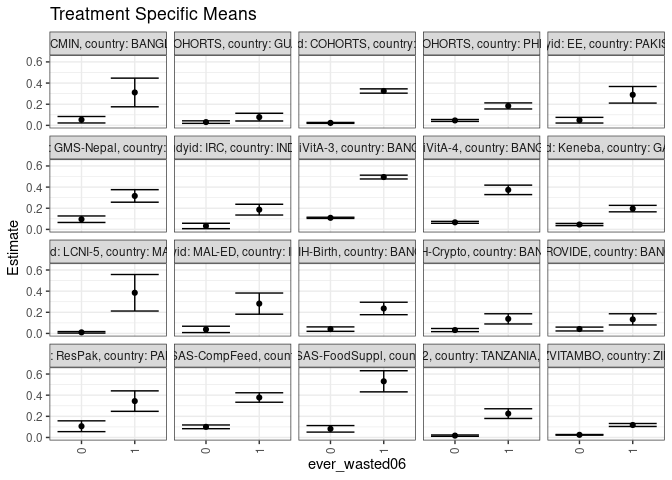

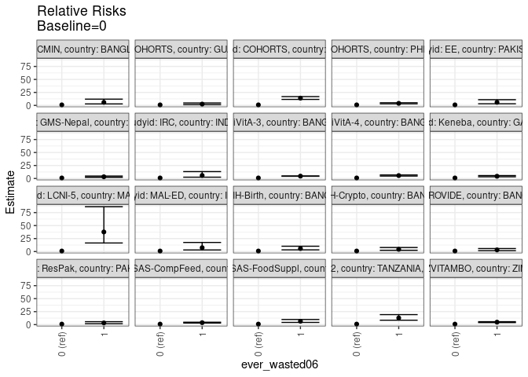

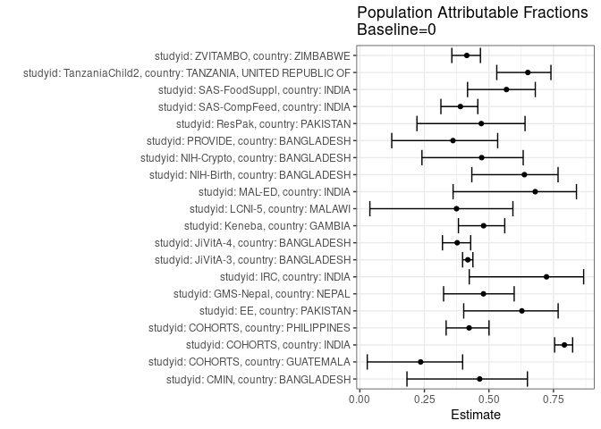

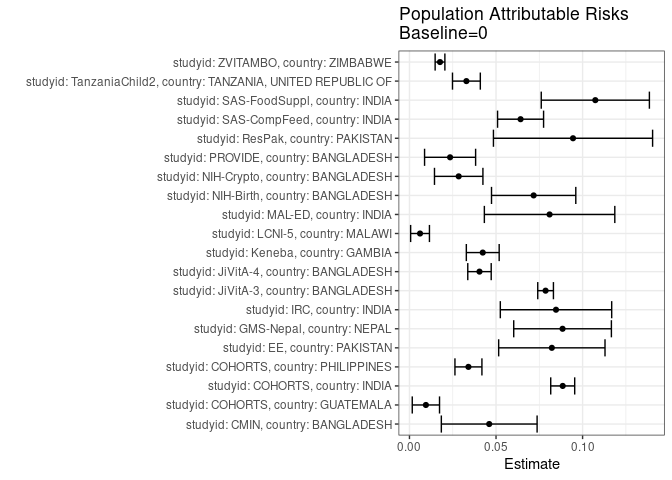

## Results Table

### Parameter: TSM

| studyid | country | intervention_level | baseline_level | estimate | ci_lower | ci_upper |
| --- | --- | --- | --- | --- | --- | --- |
| CMIN | BANGLADESH | 0 | NA | 0.0531401 | 0.0225218 | 0.0837583 |
| CMIN | BANGLADESH | 1 | NA | 0.3111111 | 0.1755804 | 0.4466418 |
| COHORTS | GUATEMALA | 0 | NA | 0.0308261 | 0.0189244 | 0.0427279 |
| COHORTS | GUATEMALA | 1 | NA | 0.0776699 | 0.0411022 | 0.1142376 |
| COHORTS | INDIA | 0 | NA | 0.0232081 | 0.0189786 | 0.0274375 |
| COHORTS | INDIA | 1 | NA | 0.3247652 | 0.3043575 | 0.3451729 |
| COHORTS | PHILIPPINES | 0 | NA | 0.0464235 | 0.0374466 | 0.0554004 |
| COHORTS | PHILIPPINES | 1 | NA | 0.1836442 | 0.1548942 | 0.2123942 |
| EE | PAKISTAN | 0 | NA | 0.0487805 | 0.0218264 | 0.0757346 |
| EE | PAKISTAN | 1 | NA | 0.2890625 | 0.2104238 | 0.3677012 |
| GMS-Nepal | NEPAL | 0 | NA | 0.0963173 | 0.0655146 | 0.1271200 |
| GMS-Nepal | NEPAL | 1 | NA | 0.3164557 | 0.2571929 | 0.3757185 |
| IRC | INDIA | 0 | NA | 0.0324324 | 0.0068747 | 0.0579902 |
| IRC | INDIA | 1 | NA | 0.1866667 | 0.1356920 | 0.2376414 |
| JiVitA-3 | BANGLADESH | 0 | NA | 0.1093807 | 0.1038966 | 0.1148648 |
| JiVitA-3 | BANGLADESH | 1 | NA | 0.4950270 | 0.4770776 | 0.5129764 |
| JiVitA-4 | BANGLADESH | 0 | NA | 0.0668279 | 0.0576497 | 0.0760060 |
| JiVitA-4 | BANGLADESH | 1 | NA | 0.3739130 | 0.3292080 | 0.4186181 |
| Keneba | GAMBIA | 0 | NA | 0.0460048 | 0.0359004 | 0.0561093 |
| Keneba | GAMBIA | 1 | NA | 0.1965944 | 0.1659410 | 0.2272479 |
| LCNI-5 | MALAWI | 0 | NA | 0.0102041 | 0.0031022 | 0.0173060 |
| LCNI-5 | MALAWI | 1 | NA | 0.3846154 | 0.2119598 | 0.5572710 |
| MAL-ED | INDIA | 0 | NA | 0.0382166 | 0.0081635 | 0.0682696 |
| MAL-ED | INDIA | 1 | NA | 0.2820513 | 0.1819735 | 0.3821290 |
| NIH-Birth | BANGLADESH | 0 | NA | 0.0408163 | 0.0198574 | 0.0617753 |
| NIH-Birth | BANGLADESH | 1 | NA | 0.2361809 | 0.1771145 | 0.2952473 |
| NIH-Crypto | BANGLADESH | 0 | NA | 0.0318352 | 0.0169346 | 0.0467358 |
| NIH-Crypto | BANGLADESH | 1 | NA | 0.1377551 | 0.0894729 | 0.1860373 |
| PROVIDE | BANGLADESH | 0 | NA | 0.0415755 | 0.0232591 | 0.0598919 |
| PROVIDE | BANGLADESH | 1 | NA | 0.1329114 | 0.0799346 | 0.1858882 |
| ResPak | PAKISTAN | 0 | NA | 0.1063830 | 0.0553818 | 0.1573842 |
| ResPak | PAKISTAN | 1 | NA | 0.3440860 | 0.2473265 | 0.4408455 |
| SAS-CompFeed | INDIA | 0 | NA | 0.1005639 | 0.0828777 | 0.1182501 |
| SAS-CompFeed | INDIA | 1 | NA | 0.3781250 | 0.3335372 | 0.4227128 |
| SAS-FoodSuppl | INDIA | 0 | NA | 0.0816993 | 0.0509717 | 0.1124270 |
| SAS-FoodSuppl | INDIA | 1 | NA | 0.5312500 | 0.4313022 | 0.6311978 |
| TanzaniaChild2 | TANZANIA, UNITED REPUBLIC OF | 0 | NA | 0.0176574 | 0.0113934 | 0.0239215 |
| TanzaniaChild2 | TANZANIA, UNITED REPUBLIC OF | 1 | NA | 0.2257053 | 0.1798189 | 0.2715918 |
| ZVITAMBO | ZIMBABWE | 0 | NA | 0.0249454 | 0.0216679 | 0.0282229 |
| ZVITAMBO | ZIMBABWE | 1 | NA | 0.1181102 | 0.1040770 | 0.1321435 |

### Parameter: E(Y)

| studyid | country | intervention_level | baseline_level | estimate | ci_lower | ci_upper |
| --- | --- | --- | --- | --- | --- | --- |
| CMIN | BANGLADESH | NA | NA | 0.0992063 | 0.0622241 | 0.1361886 |
| COHORTS | GUATEMALA | NA | NA | 0.0403147 | 0.0282199 | 0.0524094 |
| COHORTS | INDIA | NA | NA | 0.1117237 | 0.1042858 | 0.1191617 |
| COHORTS | PHILIPPINES | NA | NA | 0.0804843 | 0.0704205 | 0.0905481 |
| EE | PAKISTAN | NA | NA | 0.1310160 | 0.0967738 | 0.1652583 |
| GMS-Nepal | NEPAL | NA | NA | 0.1847458 | 0.1534039 | 0.2160876 |
| IRC | INDIA | NA | NA | 0.1170732 | 0.0859146 | 0.1482317 |
| JiVitA-3 | BANGLADESH | NA | NA | 0.1880070 | 0.1814627 | 0.1945512 |
| JiVitA-4 | BANGLADESH | NA | NA | 0.1072724 | 0.0967392 | 0.1178055 |
| Keneba | GAMBIA | NA | NA | 0.0883377 | 0.0767324 | 0.0999430 |
| LCNI-5 | MALAWI | NA | NA | 0.0163112 | 0.0075116 | 0.0251108 |
| MAL-ED | INDIA | NA | NA | 0.1191489 | 0.0776405 | 0.1606574 |
| NIH-Birth | BANGLADESH | NA | NA | 0.1125461 | 0.0859151 | 0.1391771 |
| NIH-Crypto | BANGLADESH | NA | NA | 0.0602740 | 0.0429977 | 0.0775502 |
| PROVIDE | BANGLADESH | NA | NA | 0.0650407 | 0.0455353 | 0.0845460 |
| ResPak | PAKISTAN | NA | NA | 0.2008547 | 0.1494120 | 0.2522974 |
| SAS-CompFeed | INDIA | NA | NA | 0.1647399 | 0.1451050 | 0.1843747 |
| SAS-FoodSuppl | INDIA | NA | NA | 0.1890547 | 0.1507312 | 0.2273783 |
| TanzaniaChild2 | TANZANIA, UNITED REPUBLIC OF | NA | NA | 0.0505451 | 0.0409848 | 0.0601054 |
| ZVITAMBO | ZIMBABWE | NA | NA | 0.0425869 | 0.0387663 | 0.0464075 |

### Parameter: RR

| studyid | country | intervention_level | baseline_level | estimate | ci_lower | ci_upper |
| --- | --- | --- | --- | --- | --- | --- |
| CMIN | BANGLADESH | 0 | 0 | 1.000000 | 1.000000 | 1.000000 |
| CMIN | BANGLADESH | 1 | 0 | 5.854546 | 2.843082 | 12.055828 |
| COHORTS | GUATEMALA | 0 | 0 | 1.000000 | 1.000000 | 1.000000 |
| COHORTS | GUATEMALA | 1 | 0 | 2.519612 | 1.370573 | 4.631961 |
| COHORTS | INDIA | 0 | 0 | 1.000000 | 1.000000 | 1.000000 |
| COHORTS | INDIA | 1 | 0 | 13.993644 | 11.540178 | 16.968722 |
| COHORTS | PHILIPPINES | 0 | 0 | 1.000000 | 1.000000 | 1.000000 |
| COHORTS | PHILIPPINES | 1 | 0 | 3.955846 | 3.084519 | 5.073309 |
| EE | PAKISTAN | 0 | 0 | 1.000000 | 1.000000 | 1.000000 |
| EE | PAKISTAN | 1 | 0 | 5.925781 | 3.200840 | 10.970522 |
| GMS-Nepal | NEPAL | 0 | 0 | 1.000000 | 1.000000 | 1.000000 |
| GMS-Nepal | NEPAL | 1 | 0 | 3.285555 | 2.268081 | 4.759472 |
| IRC | INDIA | 0 | 0 | 1.000000 | 1.000000 | 1.000000 |
| IRC | INDIA | 1 | 0 | 5.755556 | 2.499673 | 13.252299 |
| JiVitA-3 | BANGLADESH | 0 | 0 | 1.000000 | 1.000000 | 1.000000 |
| JiVitA-3 | BANGLADESH | 1 | 0 | 4.525726 | 4.264763 | 4.802657 |
| JiVitA-4 | BANGLADESH | 0 | 0 | 1.000000 | 1.000000 | 1.000000 |
| JiVitA-4 | BANGLADESH | 1 | 0 | 5.595166 | 4.676181 | 6.694754 |
| Keneba | GAMBIA | 0 | 0 | 1.000000 | 1.000000 | 1.000000 |
| Keneba | GAMBIA | 1 | 0 | 4.273342 | 3.264282 | 5.594325 |
| LCNI-5 | MALAWI | 0 | 0 | 1.000000 | 1.000000 | 1.000000 |
| LCNI-5 | MALAWI | 1 | 0 | 37.692308 | 16.465322 | 86.284983 |
| MAL-ED | INDIA | 0 | 0 | 1.000000 | 1.000000 | 1.000000 |
| MAL-ED | INDIA | 1 | 0 | 7.380342 | 3.114563 | 17.488630 |
| NIH-Birth | BANGLADESH | 0 | 0 | 1.000000 | 1.000000 | 1.000000 |
| NIH-Birth | BANGLADESH | 1 | 0 | 5.786432 | 3.268587 | 10.243814 |
| NIH-Crypto | BANGLADESH | 0 | 0 | 1.000000 | 1.000000 | 1.000000 |
| NIH-Crypto | BANGLADESH | 1 | 0 | 4.327131 | 2.411299 | 7.765134 |
| PROVIDE | BANGLADESH | 0 | 0 | 1.000000 | 1.000000 | 1.000000 |
| PROVIDE | BANGLADESH | 1 | 0 | 3.196869 | 1.764847 | 5.790851 |
| ResPak | PAKISTAN | 0 | 0 | 1.000000 | 1.000000 | 1.000000 |
| ResPak | PAKISTAN | 1 | 0 | 3.234409 | 1.855301 | 5.638653 |
| SAS-CompFeed | INDIA | 0 | 0 | 1.000000 | 1.000000 | 1.000000 |
| SAS-CompFeed | INDIA | 1 | 0 | 3.760047 | 3.035572 | 4.657425 |
| SAS-FoodSuppl | INDIA | 0 | 0 | 1.000000 | 1.000000 | 1.000000 |
| SAS-FoodSuppl | INDIA | 1 | 0 | 6.502500 | 4.270150 | 9.901879 |
| TanzaniaChild2 | TANZANIA, UNITED REPUBLIC OF | 0 | 0 | 1.000000 | 1.000000 | 1.000000 |
| TanzaniaChild2 | TANZANIA, UNITED REPUBLIC OF | 1 | 0 | 12.782445 | 8.492590 | 19.239232 |
| ZVITAMBO | ZIMBABWE | 0 | 0 | 1.000000 | 1.000000 | 1.000000 |
| ZVITAMBO | ZIMBABWE | 1 | 0 | 4.734751 | 3.966113 | 5.652352 |

### Parameter: PAR

| studyid | country | intervention_level | baseline_level | estimate | ci_lower | ci_upper |
| --- | --- | --- | --- | --- | --- | --- |
| CMIN | BANGLADESH | 0 | NA | 0.0460663 | 0.0184072 | 0.0737253 |
| COHORTS | GUATEMALA | 0 | NA | 0.0094885 | 0.0016135 | 0.0173635 |
| COHORTS | INDIA | 0 | NA | 0.0885157 | 0.0815921 | 0.0954393 |
| COHORTS | PHILIPPINES | 0 | NA | 0.0340608 | 0.0262698 | 0.0418519 |
| EE | PAKISTAN | 0 | NA | 0.0822356 | 0.0515223 | 0.1129488 |
| GMS-Nepal | NEPAL | 0 | NA | 0.0884285 | 0.0602192 | 0.1166378 |
| IRC | INDIA | 0 | NA | 0.0846407 | 0.0524758 | 0.1168057 |
| JiVitA-3 | BANGLADESH | 0 | NA | 0.0786263 | 0.0740956 | 0.0831569 |
| JiVitA-4 | BANGLADESH | 0 | NA | 0.0404445 | 0.0336765 | 0.0472125 |
| Keneba | GAMBIA | 0 | NA | 0.0423328 | 0.0328467 | 0.0518190 |
| LCNI-5 | MALAWI | 0 | NA | 0.0061071 | 0.0006741 | 0.0115401 |
| MAL-ED | INDIA | 0 | NA | 0.0809324 | 0.0432584 | 0.1186063 |
| NIH-Birth | BANGLADESH | 0 | NA | 0.0717298 | 0.0473884 | 0.0960712 |
| NIH-Crypto | BANGLADESH | 0 | NA | 0.0284388 | 0.0144506 | 0.0424269 |
| PROVIDE | BANGLADESH | 0 | NA | 0.0234652 | 0.0087224 | 0.0382079 |
| ResPak | PAKISTAN | 0 | NA | 0.0944717 | 0.0485066 | 0.1404368 |
| SAS-CompFeed | INDIA | 0 | NA | 0.0641760 | 0.0508857 | 0.0774662 |
| SAS-FoodSuppl | INDIA | 0 | NA | 0.1073554 | 0.0761231 | 0.1385877 |
| TanzaniaChild2 | TANZANIA, UNITED REPUBLIC OF | 0 | NA | 0.0328876 | 0.0248523 | 0.0409230 |
| ZVITAMBO | ZIMBABWE | 0 | NA | 0.0176415 | 0.0148266 | 0.0204564 |

### Parameter: PAF

| studyid | country | intervention_level | baseline_level | estimate | ci_lower | ci_upper |
| --- | --- | --- | --- | --- | --- | --- |
| CMIN | BANGLADESH | 0 | NA | 0.4643478 | 0.1824295 | 0.6490538 |
| COHORTS | GUATEMALA | 0 | NA | 0.2353613 | 0.0285962 | 0.3981161 |
| COHORTS | INDIA | 0 | NA | 0.7922729 | 0.7545128 | 0.8242248 |
| COHORTS | PHILIPPINES | 0 | NA | 0.4231983 | 0.3341790 | 0.5003159 |
| EE | PAKISTAN | 0 | NA | 0.6276755 | 0.4022682 | 0.7680807 |
| GMS-Nepal | NEPAL | 0 | NA | 0.4786496 | 0.3242992 | 0.5977417 |
| IRC | INDIA | 0 | NA | 0.7229730 | 0.4236989 | 0.8668336 |
| JiVitA-3 | BANGLADESH | 0 | NA | 0.4182094 | 0.3978900 | 0.4378430 |
| JiVitA-4 | BANGLADESH | 0 | NA | 0.3770263 | 0.3200213 | 0.4292523 |
| Keneba | GAMBIA | 0 | NA | 0.4792161 | 0.3818457 | 0.5612490 |
| LCNI-5 | MALAWI | 0 | NA | 0.3744113 | 0.0387300 | 0.5928707 |
| MAL-ED | INDIA | 0 | NA | 0.6792539 | 0.3611538 | 0.8389627 |
| NIH-Birth | BANGLADESH | 0 | NA | 0.6373369 | 0.4336799 | 0.7677559 |
| NIH-Crypto | BANGLADESH | 0 | NA | 0.4718250 | 0.2404918 | 0.6326981 |
| PROVIDE | BANGLADESH | 0 | NA | 0.3607768 | 0.1235205 | 0.5338097 |
| ResPak | PAKISTAN | 0 | NA | 0.4703486 | 0.2211076 | 0.6398339 |
| SAS-CompFeed | INDIA | 0 | NA | 0.3895594 | 0.3139197 | 0.4568599 |
| SAS-FoodSuppl | INDIA | 0 | NA | 0.5678535 | 0.4171645 | 0.6795826 |
| TanzaniaChild2 | TANZANIA, UNITED REPUBLIC OF | 0 | NA | 0.6506596 | 0.5303380 | 0.7401562 |
| ZVITAMBO | ZIMBABWE | 0 | NA | 0.4142472 | 0.3562375 | 0.4670295 |